# Data Analysis of clusters (high vehicle density areas) generated from the K-means

```python
import pandas as pd
```

Load data with 25 cluster and 30 clusters

```python
df_25 = pd.read_csv("fuel_at_centroid_with_density.csv")
```

```python
df_30 = pd.read_csv("fuel_at_centroid_with_density_30.csv")
```

```python
df_25
```

|  | x | y | timestep | density | fuel |
| --- | --- | --- | --- | --- | --- |
| 0 | 10011.566467 | 11272.663337 | 0 | 0 | 0.00 |
| 1 | 10011.566467 | 11272.663337 | 1 | 0 | 0.00 |
| 2 | 10011.566467 | 11272.663337 | 2 | 1 | 1.13 |
| 3 | 10011.566467 | 11272.663337 | 3 | 1 | 1.59 |
| 4 | 10011.566467 | 11272.663337 | 4 | 1 | 2.25 |
| ... | ... | ... | ... | ... | ... |
| 648870 | 8105.182752 | 10396.740031 | 25950 | 1 | 4.54 |
| 648871 | 8105.182752 | 10396.740031 | 25951 | 1 | 4.47 |
| 648872 | 8105.182752 | 10396.740031 | 25952 | 1 | 2.50 |
| 648873 | 8105.182752 | 10396.740031 | 25953 | 1 | 2.78 |
| 648874 | 8105.182752 | 10396.740031 | 25954 | 1 | 0.00 |

648875 rows × 5 columns

```python
df_30
```

|  | X-axis | Y-axis | Timestep | Density | Fuel |
| --- | --- | --- | --- | --- | --- |
| 0 | 11333.113335 | 9686.781000 | 0 | 0 | 0.0 |
| 1 | 11333.113335 | 9686.781000 | 1 | 0 | 0.0 |
| 2 | 11333.113335 | 9686.781000 | 2 | 0 | 0.0 |
| 3 | 11333.113335 | 9686.781000 | 3 | 0 | 0.0 |
| 4 | 11333.113335 | 9686.781000 | 4 | 0 | 0.0 |
| ... | ... | ... | ... | ... | ... |
| 786715 | 9061.086375 | 12163.665061 | 26219 | 0 | 0.0 |
| 786716 | 9061.086375 | 12163.665061 | 26220 | 0 | 0.0 |
| 786717 | 9061.086375 | 12163.665061 | 26221 | 0 | 0.0 |
| 786718 | 9061.086375 | 12163.665061 | 26222 | 0 | 0.0 |
| 786719 | 9061.086375 | 12163.665061 | 26223 | 0 | 0.0 |

786720 rows × 5 columns

Dataset with 25 clusters contains 648875 rows

Dataset with 30 clusters contains 786720 rows

Load files containing the coordinates of the clusters (25 and 30)

```python
loc_25 = pd.read_csv("location_25.csv")
```

```python
loc_30 = pd.read_csv("location_30.csv")
```

```python
loc_25
```

|  | Unnamed: 0 | x-axis | y-axis |
| --- | --- | --- | --- |
| 0 | 0 | 10011.566467 | 11272.663337 |
| 1 | 1 | 8848.577471 | 8513.383862 |
| 2 | 2 | 8386.798604 | 7515.904718 |
| 3 | 3 | 13152.126348 | 14423.977900 |
| 4 | 4 | 11394.349315 | 9048.865148 |
| 5 | 5 | 11527.259336 | 12387.681841 |
| 6 | 6 | 8374.826744 | 6972.176560 |
| 7 | 7 | 8682.464920 | 8974.308421 |
| 8 | 8 | 10005.498137 | 11629.105976 |
| 9 | 9 | 12945.477803 | 14134.184522 |
| 10 | 10 | 11155.312181 | 8419.800130 |
| 11 | 11 | 9598.254815 | 11146.420365 |
| 12 | 12 | 9320.816847 | 11908.052718 |
| 13 | 13 | 8656.215249 | 9824.539508 |
| 14 | 14 | 10612.882741 | 11616.430240 |
| 15 | 15 | 8259.794418 | 7669.265709 |
| 16 | 16 | 14082.949316 | 16086.912207 |
| 17 | 17 | 8231.774682 | 6197.402312 |
| 18 | 18 | 11651.728564 | 9388.614637 |
| 19 | 19 | 13382.377145 | 14897.902592 |
| 20 | 20 | 8487.160937 | 7315.005058 |
| 21 | 21 | 10981.514028 | 11228.473115 |
| 22 | 22 | 11933.279657 | 8188.683422 |
| 23 | 23 | 8352.310552 | 6534.457738 |
| 24 | 24 | 8105.182752 | 10396.740031 |

```python
loc_30
```

|  | Unnamed: 0 | x-axis | y-axis |
| --- | --- | --- | --- |
| 0 | 0 | 11333.113335 | 9686.781000 |
| 1 | 1 | 8712.669752 | 7367.632441 |
| 2 | 2 | 10560.351014 | 11391.913896 |
| 3 | 3 | 10586.876740 | 11323.637031 |
| 4 | 4 | 8645.146369 | 8785.640097 |
| 5 | 5 | 10929.349930 | 11742.656933 |
| 6 | 6 | 7756.116437 | 8658.783796 |
| 7 | 7 | 8141.175495 | 6607.702232 |
| 8 | 8 | 11374.831890 | 8467.758178 |
| 9 | 9 | 13450.677328 | 14850.974843 |
| 10 | 10 | 7971.564538 | 6400.383136 |
| 11 | 11 | 13532.615624 | 14981.096983 |
| 12 | 12 | 10078.317194 | 7620.088065 |
| 13 | 13 | 11575.023474 | 9726.301401 |
| 14 | 14 | 10692.517214 | 11502.185961 |
| 15 | 15 | 11069.653647 | 11895.730891 |
| 16 | 16 | 13940.659439 | 15791.264342 |
| 17 | 17 | 8463.869914 | 9147.760874 |
| 18 | 18 | 8258.154088 | 10307.703678 |
| 19 | 19 | 7870.708099 | 6092.923539 |
| 20 | 20 | 8678.332623 | 8374.747501 |
| 21 | 21 | 11706.410748 | 8199.727085 |
| 22 | 22 | 8343.624495 | 10383.325822 |
| 23 | 23 | 8672.623784 | 8168.036799 |
| 24 | 24 | 13715.531704 | 15252.863233 |
| 25 | 25 | 10747.405743 | 11847.419924 |
| 26 | 26 | 11980.346542 | 7622.013406 |
| 27 | 27 | 8753.477198 | 11770.056190 |
| 28 | 28 | 8387.810711 | 6326.288103 |
| 29 | 29 | 9061.086375 | 12163.665061 |

Let's find the count for 0 density at each cluster (i.e. how many times the density of vehicles at a perticular cluster was 0).

```python
cnt_25 = []
cent_index = 0
step=0
while step<25:
    slice_start = cent_index*25955
    slice_end = (cent_index*25955) + 25955
    temp_df = df_25.iloc[slice_start:slice_end]
    count = 0
    for i in range(len(temp_df)):
        if(temp_df['density'].iloc[i]==0):
            count+=1
    cnt_25.append(count)
    cent_index+=1
    step+=1
```

```python
cnt_30 = []
cent_index = 0
step=0
while step<30:
    slice_start = cent_index*26224
    slice_end = (cent_index*26224) + 26224
    temp_df = df_30.iloc[slice_start:slice_end]
    count = 0
    for i in range(len(temp_df)):
        if(temp_df['Density'].iloc[i]==0):
            count+=1
    cnt_30.append(count)
    cent_index+=1
    step+=1
```

```python
loc_25['0_density_count']= cnt_25
```

```python
loc_30['0_density_count']= cnt_30
```

Data showing 0 density count for 25 clusters

```python
loc_25
```

|  | Unnamed: 0 | x-axis | y-axis | 0_density_count |
| --- | --- | --- | --- | --- |
| 0 | 0 | 10011.566467 | 11272.663337 | 115 |
| 1 | 1 | 8848.577471 | 8513.383862 | 246 |
| 2 | 2 | 8386.798604 | 7515.904718 | 251 |
| 3 | 3 | 13152.126348 | 14423.977900 | 401 |
| 4 | 4 | 11394.349315 | 9048.865148 | 365 |
| 5 | 5 | 11527.259336 | 12387.681841 | 260 |
| 6 | 6 | 8374.826744 | 6972.176560 | 316 |
| 7 | 7 | 8682.464920 | 8974.308421 | 276 |
| 8 | 8 | 10005.498137 | 11629.105976 | 123 |
| 9 | 9 | 12945.477803 | 14134.184522 | 325 |
| 10 | 10 | 11155.312181 | 8419.800130 | 428 |
| 11 | 11 | 9598.254815 | 11146.420365 | 110 |
| 12 | 12 | 9320.816847 | 11908.052718 | 252 |
| 13 | 13 | 8656.215249 | 9824.539508 | 249 |
| 14 | 14 | 10612.882741 | 11616.430240 | 121 |
| 15 | 15 | 8259.794418 | 7669.265709 | 252 |
| 16 | 16 | 14082.949316 | 16086.912207 | 670 |
| 17 | 17 | 8231.774682 | 6197.402312 | 378 |
| 18 | 18 | 11651.728564 | 9388.614637 | 365 |
| 19 | 19 | 13382.377145 | 14897.902592 | 466 |
| 20 | 20 | 8487.160937 | 7315.005058 | 251 |
| 21 | 21 | 10981.514028 | 11228.473115 | 191 |
| 22 | 22 | 11933.279657 | 8188.683422 | 417 |
| 23 | 23 | 8352.310552 | 6534.457738 | 368 |
| 24 | 24 | 8105.182752 | 10396.740031 | 175 |

Storing this 0 density count data into respective csv file

```python
loc_25.to_csv('centroid_0_density_25.csv',index=False)
loc_30.to_csv('centroid_0_density_30.csv',index=False)
```

Loading and analyzing the 0 density count data

```python
zerodensity_25 = pd.read_csv('centroid_0_density_25.csv')
```

```python
zerodensity_30 = pd.read_csv('centroid_0_density_30.csv')
```

```python
zerodensity_25
```

|  | Unnamed: 0 | x-axis | y-axis | 0_density_count |
| --- | --- | --- | --- | --- |
| 0 | 0 | 10011.566467 | 11272.663337 | 115 |
| 1 | 1 | 8848.577471 | 8513.383862 | 246 |
| 2 | 2 | 8386.798604 | 7515.904718 | 251 |
| 3 | 3 | 13152.126348 | 14423.977900 | 401 |
| 4 | 4 | 11394.349315 | 9048.865148 | 365 |
| 5 | 5 | 11527.259336 | 12387.681841 | 260 |
| 6 | 6 | 8374.826744 | 6972.176560 | 316 |
| 7 | 7 | 8682.464920 | 8974.308421 | 276 |
| 8 | 8 | 10005.498137 | 11629.105976 | 123 |
| 9 | 9 | 12945.477803 | 14134.184522 | 325 |
| 10 | 10 | 11155.312181 | 8419.800130 | 428 |
| 11 | 11 | 9598.254815 | 11146.420365 | 110 |
| 12 | 12 | 9320.816847 | 11908.052718 | 252 |
| 13 | 13 | 8656.215249 | 9824.539508 | 249 |
| 14 | 14 | 10612.882741 | 11616.430240 | 121 |
| 15 | 15 | 8259.794418 | 7669.265709 | 252 |
| 16 | 16 | 14082.949316 | 16086.912207 | 670 |
| 17 | 17 | 8231.774682 | 6197.402312 | 378 |
| 18 | 18 | 11651.728564 | 9388.614637 | 365 |
| 19 | 19 | 13382.377145 | 14897.902592 | 466 |
| 20 | 20 | 8487.160937 | 7315.005058 | 251 |
| 21 | 21 | 10981.514028 | 11228.473115 | 191 |
| 22 | 22 | 11933.279657 | 8188.683422 | 417 |
| 23 | 23 | 8352.310552 | 6534.457738 | 368 |
| 24 | 24 | 8105.182752 | 10396.740031 | 175 |

```python
zerodensity_30
```

|  | Unnamed: 0 | x-axis | y-axis | 0_density_count |
| --- | --- | --- | --- | --- |
| 0 | 0 | 11333.113335 | 9686.781000 | 785 |
| 1 | 1 | 8712.669752 | 7367.632441 | 596 |
| 2 | 2 | 10560.351014 | 11391.913896 | 554 |
| 3 | 3 | 10586.876740 | 11323.637031 | 555 |
| 4 | 4 | 8645.146369 | 8785.640097 | 628 |
| 5 | 5 | 10929.349930 | 11742.656933 | 556 |
| 6 | 6 | 7756.116437 | 8658.783796 | 548 |
| 7 | 7 | 8141.175495 | 6607.702232 | 759 |
| 8 | 8 | 11374.831890 | 8467.758178 | 785 |
| 9 | 9 | 13450.677328 | 14850.974843 | 649 |
| 10 | 10 | 7971.564538 | 6400.383136 | 843 |
| 11 | 11 | 13532.615624 | 14981.096983 | 724 |
| 12 | 12 | 10078.317194 | 7620.088065 | 730 |
| 13 | 13 | 11575.023474 | 9726.301401 | 781 |
| 14 | 14 | 10692.517214 | 11502.185961 | 558 |
| 15 | 15 | 11069.653647 | 11895.730891 | 573 |
| 16 | 16 | 13940.659439 | 15791.264342 | 791 |
| 17 | 17 | 8463.869914 | 9147.760874 | 690 |
| 18 | 18 | 8258.154088 | 10307.703678 | 776 |
| 19 | 19 | 7870.708099 | 6092.923539 | 864 |
| 20 | 20 | 8678.332623 | 8374.747501 | 544 |
| 21 | 21 | 11706.410748 | 8199.727085 | 753 |
| 22 | 22 | 8343.624495 | 10383.325822 | 802 |
| 23 | 23 | 8672.623784 | 8168.036799 | 507 |
| 24 | 24 | 13715.531704 | 15252.863233 | 705 |
| 25 | 25 | 10747.405743 | 11847.419924 | 564 |
| 26 | 26 | 11980.346542 | 7622.013406 | 665 |
| 27 | 27 | 8753.477198 | 11770.056190 | 732 |
| 28 | 28 | 8387.810711 | 6326.288103 | 773 |
| 29 | 29 | 9061.086375 | 12163.665061 | 611 |

```python
max(zerodensity_25['0_density_count'])
```

```
670
```

```python
max(zerodensity_30['0_density_count'])
```

```
864
```

```python
zerodensity_25[zerodensity_25['0_density_count']==25954]
```

|  | Unnamed: 0 | x-axis | y-axis | 0_density_count |
| --- | --- | --- | --- | --- |

```python
zerodensity_30[zerodensity_30['0_density_count']==26224]
```

|  | Unnamed: 0 | x-axis | y-axis | 0_density_count |
| --- | --- | --- | --- | --- |

Followings cells will help to get better insight of 0 density counts

```python
#zerodensity_25[zerodensity_25['0_density_count']>12400].count()
```

```python
#zerodensity_30[zerodensity_30['0_density_count']<2400]
```

```python
#zerodensity_25[zerodensity_25['0_density_count']<1000].count()
```

```python
#zerodensity_30[zerodensity_30['0_density_count']<800].count()
```

```python
#zerodensity_25[zerodensity_25['0_density_count']<900].count()
```

```python
#zerodensity_30[zerodensity_30['0_density_count']<600]
```

```python
import numpy as np
import statistics
```

```python
distance_25 = []
temp_dis_25 = []
for i,j in zip (zerodensity_25['x-axis'],zerodensity_25['y-axis']):
    for k,l in zip (zerodensity_25['x-axis'],zerodensity_25['y-axis']):
        temp_dis_25.append(np.linalg.norm(np.array([i,j])-np.array([k,l])))
    distance_25.append(statistics.mean(temp_dis_25))
```

```python
distance_30 = []
temp_dis_30 = []
for i,j in zip (zerodensity_30['x-axis'],zerodensity_30['y-axis']):
    for k,l in zip (zerodensity_30['x-axis'],zerodensity_30['y-axis']):
        temp_dis_30.append(np.linalg.norm(np.array([i,j])-np.array([k,l])))
    distance_30.append(statistics.mean(temp_dis_30))
```

Mean distance for 25 cluster

```python
distance_25
```

```
[2958.8214990109823,
 3074.145650131489,
 3278.7729060515426,
 3807.7191745202663,
 3691.405751085244,
 3689.3681612466416,
 3734.9424550509384,
 3660.3072741605783,
 3596.270570468898,
 3749.6837676694627,
 3713.7947210514967,
 3652.843942526984,
 3630.058883675539,
 3591.4065441213475,
 3559.1314211655263,
 3566.3235225650806,
 3772.692283592602,
 3821.076258440496,
 3792.0995061151957,
 3893.6581730508574,
 3887.302032323274,
 3850.3446526609778,
 3847.7600283161787,
 3867.8475041064758,
 3849.7167987961193]
```

Mean distance for 30 clusters

```python
distance_30
```

```
[3140.669522608653,
 3402.7967853905407,
 3297.8404496710023,
 3241.4282403351017,
 3222.0735583384617,
 3231.850237592325,
 3284.7727020144202,
 3409.9094250282183,
 3410.194463231395,
 3670.4256580653855,
 3745.302238446809,
 3944.257494503993,
 3908.0057208662797,
 3860.1998078253628,
 3812.1052227214727,
 3785.956814938723,
 3971.3303705122166,
 3926.6533499489906,
 3894.2245181179965,
 3938.0423239680154,
 3904.345310567399,
 3893.016256332535,
 3866.513396270817,
 3843.0047862975975,
 3945.7493521024444,
 3920.684308545381,
 3926.112181712478,
 3913.337379624736,
 3930.3419020755277,
 3921.372358878357]
```

```python
print(min(distance_25))
print(min(distance_30))
```

```
2958.8214990109823
3140.669522608653
```

```python
print(statistics.mean(distance_25))
print(statistics.mean(distance_30))
```

```
3661.499739276168
3705.4172045510877
```

```python
print(max(distance_25))
print(max(distance_30))
```

```
3893.6581730508574
3971.3303705122166
```

```python
import matplotlib.pyplot as plt
```

Graphical representation of 25 and 30 clusters

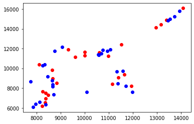

```python
plt.plot(loc_25['x-axis'],loc_25['y-axis'],'ro')
plt.plot(loc_30['x-axis'],loc_30['y-axis'],'bo')
```

Data where the density of vehicle is 0

```python
df_25[df_25['density']==0]
```

|  | x | y | timestep | density | fuel |
| --- | --- | --- | --- | --- | --- |
| 0 | 10011.566467 | 11272.663337 | 0 | 0 | 0.0 |
| 1 | 10011.566467 | 11272.663337 | 1 | 0 | 0.0 |
| 25631 | 10011.566467 | 11272.663337 | 25631 | 0 | 0.0 |
| 25632 | 10011.566467 | 11272.663337 | 25632 | 0 | 0.0 |
| 25633 | 10011.566467 | 11272.663337 | 25633 | 0 | 0.0 |
| ... | ... | ... | ... | ... | ... |
| 648787 | 8105.182752 | 10396.740031 | 25867 | 0 | 0.0 |
| 648788 | 8105.182752 | 10396.740031 | 25868 | 0 | 0.0 |
| 648789 | 8105.182752 | 10396.740031 | 25869 | 0 | 0.0 |
| 648790 | 8105.182752 | 10396.740031 | 25870 | 0 | 0.0 |
| 648791 | 8105.182752 | 10396.740031 | 25871 | 0 | 0.0 |

7371 rows × 5 columns

```python
df_30[df_30['Density']==0]
```

|  | X-axis | Y-axis | Timestep | Density | Fuel |
| --- | --- | --- | --- | --- | --- |
| 0 | 11333.113335 | 9686.781000 | 0 | 0 | 0.0 |
| 1 | 11333.113335 | 9686.781000 | 1 | 0 | 0.0 |
| 2 | 11333.113335 | 9686.781000 | 2 | 0 | 0.0 |
| 3 | 11333.113335 | 9686.781000 | 3 | 0 | 0.0 |
| 4 | 11333.113335 | 9686.781000 | 4 | 0 | 0.0 |
| ... | ... | ... | ... | ... | ... |
| 786715 | 9061.086375 | 12163.665061 | 26219 | 0 | 0.0 |
| 786716 | 9061.086375 | 12163.665061 | 26220 | 0 | 0.0 |
| 786717 | 9061.086375 | 12163.665061 | 26221 | 0 | 0.0 |
| 786718 | 9061.086375 | 12163.665061 | 26222 | 0 | 0.0 |
| 786719 | 9061.086375 | 12163.665061 | 26223 | 0 | 0.0 |

20401 rows × 5 columns

Variation in Density with respect to timestep

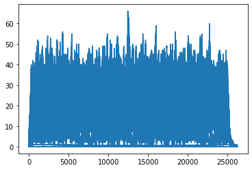

```python
plt.plot(df_30['Timestep'], df_30['Density'])
#plt.axis([min(df_30['X-axis'].values), max(df_30['X-axis'].values),min(df_30['Y-axis'].values), max(df_30['Y-axis'].values)])
plt.show()
```

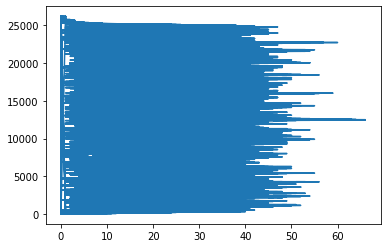

```python
plt.plot(df_30['Density'], df_30['Timestep'])
#plt.axis([min(df_30['X-axis'].values), max(df_30['X-axis'].values),min(df_30['Y-axis'].values), max(df_30['Y-axis'].values)])
plt.show()
```

```python
import math
```

```python
tempdf_30=df_30
temploc_30=loc_30
tempdf_25=df_25
temploc_25=loc_25
```

Rounding of the coordinates of cluster upto 4 decimal points

```python
tempdf_30['X-axis'] = round(tempdf_30['X-axis'],4)
temploc_30['x-axis'] = round(temploc_30['x-axis'],4)
tempdf_25['x'] = round(tempdf_25['x'],4)
temploc_25['x-axis'] = round(temploc_25['x-axis'],4)
```

Variation of density with respect to timestep for each and every cluster. Blue represents the 30 clusters, and Red represents the 25 clusters

```
30 - 11333.1133
25 - 10011.5665
```

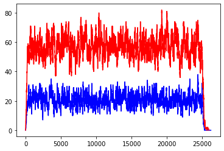

```
30 - 8712.6698
25 - 8848.5775
```

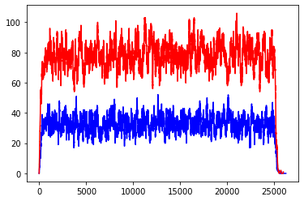

```
30 - 10560.351
25 - 8386.7986
```

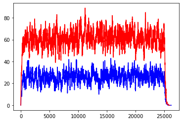

```
30 - 10586.8767
25 - 13152.1263
```

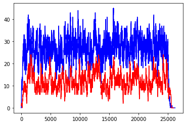

```
30 - 8645.1464
25 - 11394.3493
```

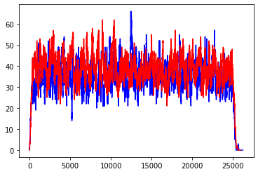

```
30 - 10929.3499
25 - 11527.2593
```

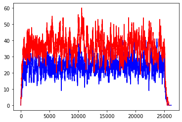

```
30 - 7756.1164
25 - 8374.8267
```

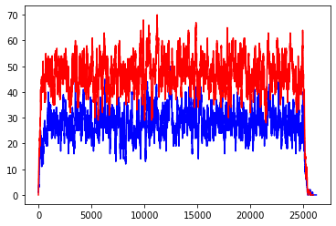

```
30 - 8141.1755
25 - 8682.4649
```

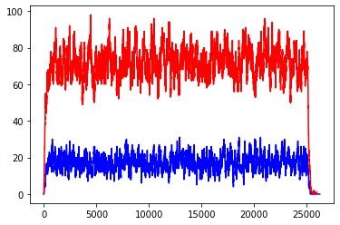

```
30 - 11374.8319
25 - 10005.4981
```

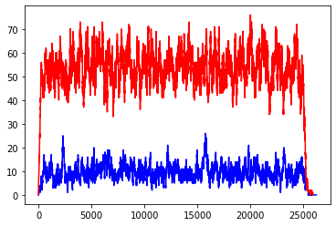

```
30 - 13450.6773
25 - 12945.4778
```

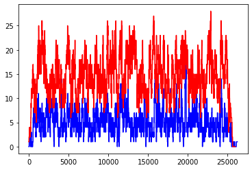

```
30 - 7971.5645
25 - 11155.3122
```

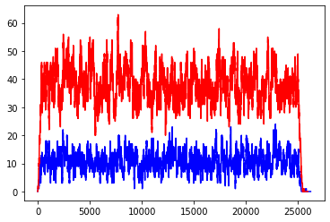

```
30 - 13532.6156
25 - 9598.2548
```

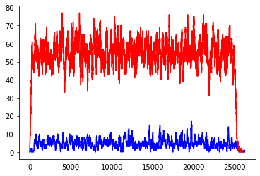

```
30 - 10078.3172
25 - 9320.8168
```

[13 more figures not shown]

```python
for i,j in zip(temploc_30['x-axis'],temploc_25['x-axis']):
    print("30 - " + str(i))
    print("25 - " + str(j))

    plt.plot(range(26224), tempdf_30['Density'][tempdf_30['X-axis']==i],"b")
    plt.plot(range(25955), tempdf_25['density'][tempdf_25['x']==j],"r")
#    plt.axis([min(tempdf_30['Timestep'].values), max(tempdf_30['Timestep'].values),min(tempdf_30['Density'].values), max(tempdf_30['Density'].values)])
    plt.show()
```

Density variation representation (only for 30 clusters)

```
30 - 11333.1133
```

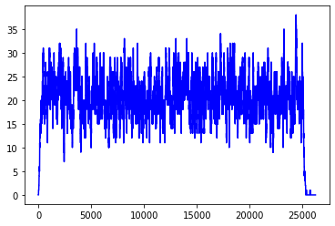

```
30 - 8712.6698
```

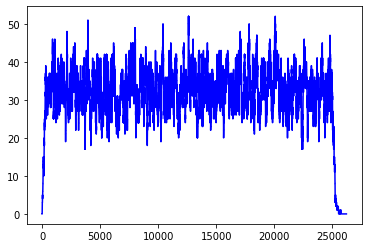

```
30 - 10560.351
```

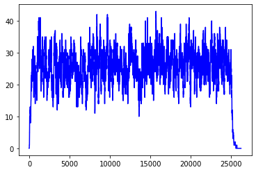

```
30 - 10586.8767
```

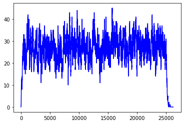

```
30 - 8645.1464
```

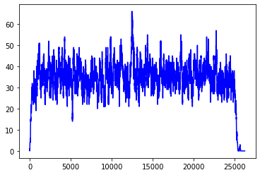

```
30 - 10929.3499
```

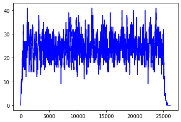

```
30 - 7756.1164
```

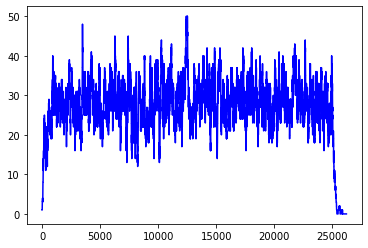

```
30 - 8141.1755
```

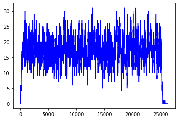

```
30 - 11374.8319
```

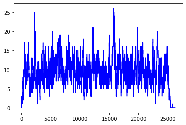

```
30 - 13450.6773
```

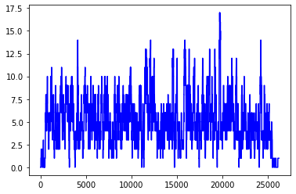

```
30 - 7971.5645
```

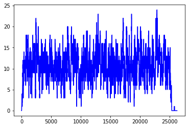

```
30 - 13532.6156
```

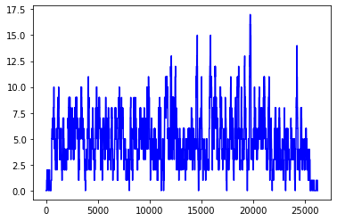

```
30 - 10078.3172
```

[18 more figures not shown]

```python
for i in temploc_30['x-axis']:
    print("30 - " + str(i))

    plt.plot(range(26224), tempdf_30['Density'][tempdf_30['X-axis']==i],"b")
#    plt.axis([min(tempdf_30['Timestep'].values), max(tempdf_30['Timestep'].values),min(tempdf_30['Density'].values), max(tempdf_30['Density'].values)])
    plt.show()
```

Storing the data of perticular cluster into a csv file

1. cluster with x coordinate 8678.3326
2. cluster with x coordinate 9061.0864

```python
8678.3326
df_8678 = tempdf_30[tempdf_30['X-axis']==8678.3326]
```

```python
df_8678
```

|  | X-axis | Y-axis | Timestep | Density | Fuel |
| --- | --- | --- | --- | --- | --- |
| 524480 | 8678.3326 | 8374.747501 | 0 | 1 | 1.13 |
| 524481 | 8678.3326 | 8374.747501 | 1 | 1 | 1.29 |
| 524482 | 8678.3326 | 8374.747501 | 2 | 1 | 1.57 |
| 524483 | 8678.3326 | 8374.747501 | 3 | 1 | 2.53 |
| 524484 | 8678.3326 | 8374.747501 | 4 | 1 | 2.57 |
| ... | ... | ... | ... | ... | ... |
| 550699 | 8678.3326 | 8374.747501 | 26219 | 0 | 0.00 |
| 550700 | 8678.3326 | 8374.747501 | 26220 | 0 | 0.00 |
| 550701 | 8678.3326 | 8374.747501 | 26221 | 0 | 0.00 |
| 550702 | 8678.3326 | 8374.747501 | 26222 | 0 | 0.00 |
| 550703 | 8678.3326 | 8374.747501 | 26223 | 0 | 0.00 |

26224 rows × 5 columns

```python
max(df_8678['Density'])
```

```
61
```

```python
df_8678.to_csv('df_8678.csv',index=False)
```

```python
df_8678[df_8678['Density']==61]
```

|  | X-axis | Y-axis | Timestep | Density | Fuel |
| --- | --- | --- | --- | --- | --- |
| 537076 | 8678.3326 | 8374.747501 | 12596 | 61 | 139.81 |
| 537077 | 8678.3326 | 8374.747501 | 12597 | 61 | 159.17 |

```python
df_9061 = tempdf_30[tempdf_30['X-axis']==9061.0864]
df_9061.to_csv('df_9061.csv',index=False)
```